# 2. Nizovi podataka i linijski dijagrami

U ovoj lekciji ćeš naučiti:

1. kako da se krećeš kroz Džupajter radnu svesku;
2. kako se zapisuju nizovi podataka; i
3. kako se prikazuju nizovi podataka linijskim dijagramima.

## 2.1. Još malo o Džupajter radnoj svesci

Džupajter radna sveska se sastoji iz niza ćelija, a svaka ćelija može da sadrži tekst, matematički izraz ili niz Pajton naredbi. Niz ikona pri vrhu strane ti omogućuje da barataš ćelijama Džupajter radne sveske na razne načine.

Dugme **Run** smo već koristili. Pogledajmo sada čemu služe još četiri dugmeta:

[figure not shown]

- Klik na dugme koje liči na disketu (prva sleva) će snimiti radnu svesku.
- Klik na dugme sa znakom **+** će dodati novu ćeliju ispod aktivne ćelije. (Ćeliju aktiviraš tako što klikneš na nju; aktivna ćelija ima ***zeleni*** ili ***plavi*** okvir.)
- Strelice na gore i na dole pomeraju radnu ćeliju za jedno mesto gore ili dole.

Na primer, čitaš ovaj tekst i odjednom osetiš snažnu želju da izračunaš vrednost izraza $1 + \frac 12 + \frac 13 + \frac 14 + \frac 15 + \frac 16 + \frac 17$. Tada treba da klikneš na ovu ćeliju (koju upravo čitaš) i onda na dugme sa znakom **+**. U novoj ćeliji koja će se pojaviti ispod možeš da uneseš izraz, a Pajton će ga izračunati:

```python
1 + 1/2 + 1/3 + 1/4 + 1/5 + 1/6 + 1/7
```

```
2.5928571428571425
```

U osam ćelija koje slede navedeni su stihovi poznate engleske dečije brojalice. Stihovi su ispreturani. Koristeći dugmiće sa strelicama preuredi ćelije tako da dobiješ tekst brojalice.

*Once I caught a fish alive,*

*Then I let it go again.*

*Which finger did it bite?*

*Why did you let it go?*

*Because it bit my finger so.*

*This little finger on my right.*

*One, two, three, four, five,*

*Six, seven, eight, nine, ten,*

## 2.2. Zapisivanje nizova podataka

Nizovi podataka se u Pajtonu zapisuju unutar uglastih zagrada, u obliku *liste*. Na primer, ocene nekog učenika iz jednog predmeta mogu da se zapišu kao niz ovako:

```python
ocene = [2, 4, 5, 3, 5]
```

Sistem nije vratio nikakav izlaz, naravno. On je samo konstatovao da promenljiva `ocene` sada sadrži niz koji se sastoji od pet brojeva. Da bismo se uverili da je to tako, zatražićemo od sistema da izračuna sledeći izraz:

```python
ocene
```

```
[2, 4, 5, 3, 5]
```

Moguće je raditi i sa nizovima stringova:

```python
predmeti = ["matematika", "srpski", "likovno", "istorija", "fizičko"]
```

Sistem ni ovaj put nije vratio nikakav izlaz, već je samo zapamtio da promenljiva `predmeti` sada sadrži niz od pet stringova (imena predmeta). Evo sadržaja promenljive `predmeti`:

```python
predmeti
```

```
['matematika', 'srpski', 'likovno', 'istorija', 'fizičko']
```

Dužinu niza možemo dobiti pozivom ugrađene funkcije `len` (što je skraćenica engleske reči *length* koja znači "dužina"):

```python
len(predmeti)
```

```
5
```

## 2.3. Prikazivanje nizova podataka

U narednoj ćeliji prikazan je procenjeni broj stanovnika naše planete u raznim istorijskim periodima, pri čemu je broj ljudi iskazan u milijardama:

```python
godine = [1000,  1500, 1650, 1750, 1804, 1850, 1900, 1930, 1950, 1960, 1974, 1980, 1987, 1999, 2011, 2020, 2023, 2030, 2037, 2045, 2055, 2100]
ljudi  = [0.275, 0.45, 0.5,  0.7,  1,    1.2,  1.6,  2,    2.55, 3,    4,    4.5,  5,    6,    7,    7.8,  8,    8.5,  9,    9.5,  10,   11.2]
```

Želeli bismo da prikažemo ove podatke u vidu grafikona (da ih *vizuelizujemo*) zato što ljudi najlakše i najbrže obrađuju vizuelne podatke. (Verovatno znaš za izreku da *jedna slika vredi više od hiljadu reči*.)

Pajton ima razne biblioteke za vizuelizaciju podataka, a mi ćemo koristiti biblioteku koja se zove `matplotlib.pyplot`. Pošto je ovo ime veoma dugačko i komplikovano i pošto će nam trebati mnogo funkcija iz te biblioteke nećemo uvoziti funkcije jednu po jednu već ćemo uvesti celu biblioteku i pri tome joj dati kraće ime (takoreći, nadimak) `plt`. (Engleska reč *plot* znači "iscrtati", a `plt` je skraćeno od `plot`.)

```python
import matplotlib.pyplot as plt
```

Sada su nam sve funkcije iz ove biblioteke dostupne. Važno je napomenuti da *jedan* `import` *važi za celu radnu svesku!* Dakle, dovoljno je biblioteku uvesti jednom u radnoj svesci. Takođe je važno reći da ćemo u novoj radnoj svesci morati ponovo da "importujemo" biblioteke koje nam trebaju za rad.

**Jedan import po radnoj svesci!**

Ako se zabuniš pa pokušaš biblioteku da importuješ dva puta -- nema brige. Pajton se neće buniti, ali neće gubiti vreme na to da dva puta učitava istu biblioteku.

Natrag na crtanje grafikona. Najjednostavniji grafikon se može dobiti ovako:

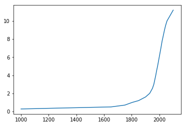

```python
plt.plot(godine, ljudi)
plt.show()
plt.close()
```

Funkcija `plot(godine, ljudi)` kaže sistemu da treba nacrtati grafikon kome su na horizontalnu osu ($x$-osa) naneti podaci iz niza `godine`, a na vertikalnu osu ($y$-osa) podaci iz niza `ljudi`. Funkcija `show` potom prikazuje grafikon. (Engleska reč *plot* znači "iscrtati", a engleska reč *show* znači "prikazati".) Konačno, funkcija `close` završava rad na grafikonu (engleska reč *close* znači "zatvori").

Vidimo da su podaci predstavljeni linijom. Zato se ova vrsta grafikona zove *linijski grafikon*.

Pošto nismo uvozili pojedinačne funkcije već smo celu biblioteku uvezli pod nadimkom `plt`, funkcije `plot`, `show` i `close` moramo da pozovemo "punim prezimenom i imenom": `plt.plot`, `plt.show` i `plt.close`.

U narednom koraku ćemo grafikonu dodati naslov koristeći funkciju `title` (engleska reč *title* znači "naslov"):

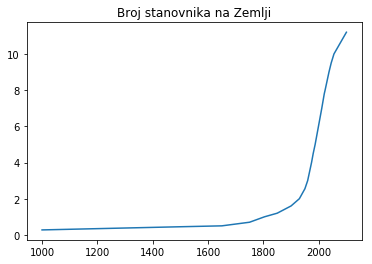

```python
plt.plot(godine, ljudi)
plt.title("Broj stanovnika na Zemlji")
plt.show()
plt.close()
```

Možemo staviti oznaku i na vertikalnu osu da bismo naglasili da se radi o brojevima koji su iskazani u milijardama. Za to koristimo funkciju `ylabel` ("oznaka na $y$-osi"; engleska reč *label* znači "oznaka"):

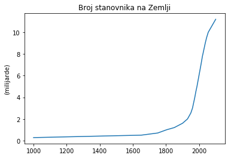

```python
plt.plot(godine, ljudi)
plt.title("Broj stanovnika na Zemlji")
plt.ylabel("(milijarde)")
plt.show()
plt.close()
```

Da zaključimo: funkcijama `plot`, `title` i `ylabel` dodajemo podatke na grafikon, i tek kada smo uneli sve podatke koje želimo da imamo na grafikonu crtamo grafikon pozivom funkcije `show`. Na kraju pozivamo funkciju `close` da počisti za nama.

## 2.4. Zadaci

**Zadatak 1.** Sledeći program crta grafikon koji predstavlja procenjeni broj ljudi na Zemlji u raznim periodima:

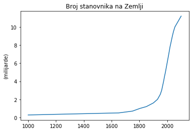

```python
import matplotlib.pyplot as plt
plt.plot(godine, ljudi)
plt.title("Broj stanovnika na Zemlji")
plt.ylabel("(milijarde)")
plt.show()
plt.close()
```

1. Čemu služi naredba `import ... as ..`?
2. Zašto pišemo `plt.plot`, a ne prosto `plot`?
3. Čemu služi funkcija `plot`?
4. Čemu služe funkcije `title` i `ylabel`?
5. Čemu služe funkcije `show` i `close`?

Sledeće zadatke reši u Džupajteru.

**Zadatak 2.** U narednoj ćeliji dati su podaci o masi (u kilogramima) i dužini/visini (u centimetrima) jednog dečaka od njegovog šestog meseca pa do njegovih 6,5 godina.

```python
merenja   = ["6 mes", "1,5 god", "2,5 god", "3,5 god", "4,5 god", "5,5 god", "6,5 god"]
masaKG    = [5.9,     11.5,      14.8,      20.5,      22.0,      24.2,      29.0     ]
visinaCM  = [62.0,    84.0,      97.0,      115.0,     122.5,     131.5,     135.0    ]
```

Prikaži jednim grafikonom kako se menjala njegova masa, a drugim kako se menjala njegova visina.

**Zadatak 3.** *Indeks telesne težine* (engl. *body mass index*, BMI) predstavlja količnik telesne mase izražene u kilogramima i kvadrata telesne visine u izražene u metrima:

$$\hbox{BMI} = \frac{\hbox{masa u kilogramima}}{(\hbox{visina u metrima})^2}$$

Za dečaka iz Zadatka 2 prikaži grafikonom promenu njegovog indeksa telesne težine. Može ti pomoći sledeći mali Pajton program koji računa njegove indekse telesne težine za svako merenje.

```python
BMI = [0, 0, 0, 0, 0, 0, 0]
for i in range(0, 7):
    BMI[i] = masaKG[i] / (visinaCM[i] / 100.0)**2
```

**Zadatak 4.** Procenjuje se da je Kina na dan 1.7.2019. imala 1.420.062.022 stanovnika. Broj stanovnika u Kini se svake godine poveća za 0,35%. Pod pretpostavkom da se godišnji rast broja stanovnika u Kini neće menjati, prikazati grafikonom očekivani broj stanovnika Kine u narednih deset godina.

**Zadatak 5.** Svaka država ima organizovanu službu koja pažljivo beleži podatke o vremenskim prilikama zato što je to važno za saobraćaj, poljoprivredu, ali i sve ostale privredne grane.

Na sajtu Republičkog hidrometeorološkog zavoda Srbije (http://www.hidmet.gov.rs/) u meniju sa leve strane klikni na "Meteorologija", pa "Klimatologija", pa na "Normale". Potom u spisku stanica za osmatranje koji se pojavio odaberi stanicu najbližu tvojoj školi, preuzmi najniže i najviše temperature u periodu 1981-2010 (redovi "Apsolutni maksimum" i "Apsolutni minimum") i prikaži te podatke.